# Geog533 Lab 4

Dr. Qiusheng Wu

## Question 1

The number of points scored by each team in a tournament is normally distributed, with mean μ = 32 and standard deviation σ = 7. What is the probability of:

### 1a

A team scoring 20 points or fewer? Plot the density function and shade the area. (5 pt.)

```r
pnorm(20,mean = 32,sd = 7)
```

```
[1] 0.04323813
```

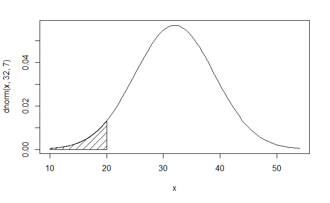

```r
curve(dnorm(x,32,7),from = 10,to = 54)
cord.x <- c(10,seq(10,20,0.01),20)
cord.y <- c(0,dnorm(seq(10,20,0.01),mean = 32,sd = 7),0)
polygon(cord.x,cord.y,density = 10)
```

### 1b

A team scoring more than 35 points? Plot the density function and shade the area. (5 pt.)

```r
pnorm(35,mean = 32,sd = 7,lower.tail = FALSE)
```

```
[1] 0.3341176
```

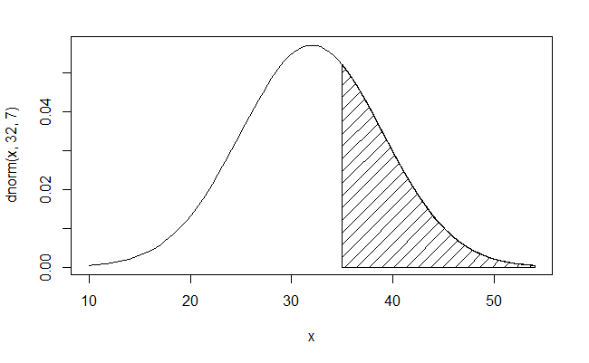

```r
curve(dnorm(x,32,7),from = 10,to = 54)
cord.x <- c(35,seq(35,54,0.01),54)
cord.y <- c(0,dnorm(seq(35,54,0.01),mean = 32,sd = 7),0)
polygon(cord.x,cord.y,density = 10)
```

### 1c

A team scoring between 20 and 40 points? Plot the density function and shade the area. (5 pt.)

```r
pnorm(40,mean = 32,sd = 7) - pnorm(20,mean = 32,sd = 7)
```

```
[1] 0.8302129
```

```r
diff(pnorm(c(20,40),mean = 32,sd = 7))
```

```
[1] 0.8302129
```

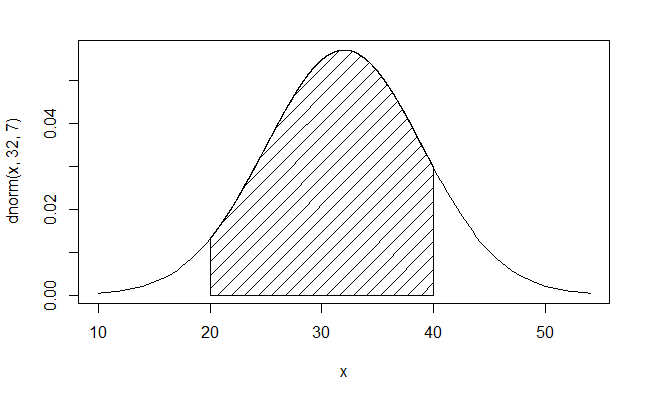

```r
curve(dnorm(x,32,7),from = 10,to = 54)
cord.x <- c(20,seq(20,40,0.01),40)
cord.y <- c(0,dnorm(seq(20,40,0.01),mean = 32,sd = 7),0)
polygon(cord.x,cord.y,density = 10)
```

## Question 2

The number of comments per post on a social media site is exponentially distributed, with the average post receiving ten comments. What percentage of posts get:

### 2a

Fewer than three comments? Plot the density function and shade the area. (5 pt.)

```r
pexp(3,rate = 1/10)
```

```
[1] 0.2591818
```

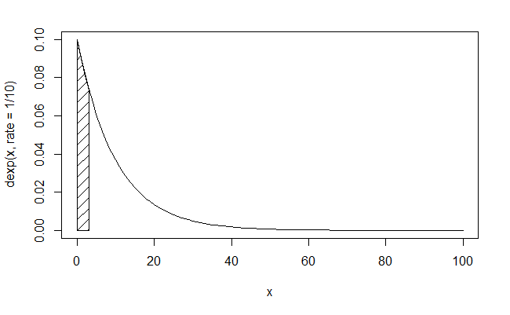

```r
curve(dexp(x,rate = 1/10),from = 0,to = 100)
cord.x <- c(0,seq(0,3,0.01),3)
cord.y <- c(0,dexp(seq(0,3,0.01),rate = 1/10),0)
polygon(cord.x,cord.y,density = 10)
```

### 2b

More than 20 comments? Plot the density function and shade the area. (5 pt.)

```r
pexp(20,rate = 1/10,lower.tail = FALSE)
```

```
[1] 0.1353353
```

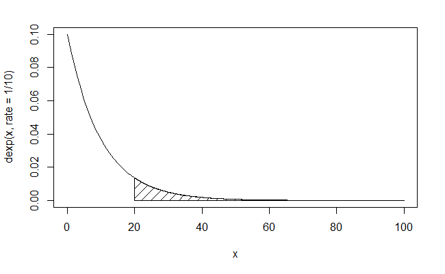

```r
curve(dexp(x,rate = 1/10),from = 0,to = 100)
cord.x <- c(20,seq(20,100,0.01),100)
cord.y <- c(0,dexp(seq(20,100,0.01),rate = 1/10),0)
polygon(cord.x,cord.y,density = 10)
```

### 2c

Between five and ten comments? Plot the density function and shade the area. (5 pt.)

```r
diff(pexp(c(5,10),rate = 1/10))
```

```
[1] 0.2386512
```

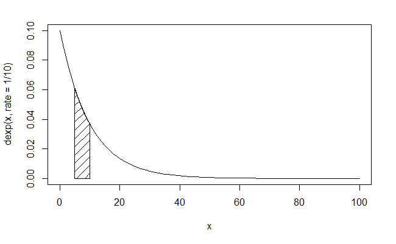

```r
curve(dexp(x,rate = 1/10),from = 0,to = 100)
cord.x <- c(5,seq(5,10,0.01),10)
cord.y <- c(0,dexp(seq(5,10,0.01),rate = 1/10),0)
polygon(cord.x,cord.y,density = 10)
```

## Question 3

Basic raster creation and calculation:

### 3a

Create a first raster (30 rows × 30 columns) and assign values to the raster based on random values from a uniform distribution. Plot the raster and the histogram. (5 pt.)

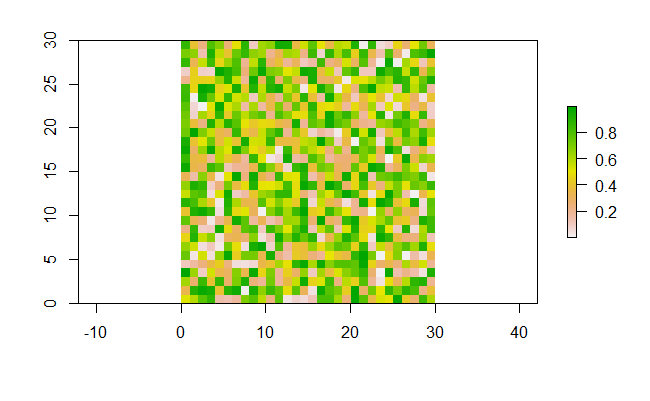

```r
library(raster)
ras1 <- raster(nrows=30,ncols=30,xmn=0,xmx=30,ymn=0,ymx=30)
ras1[] = runif(ncell(ras1))
plot(ras1)
```

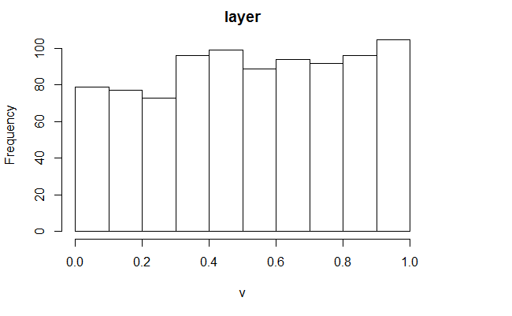

```r
hist(ras1)
```

### 3b

Create a second raster (30 rows × 30 columns) and assign values to the raster based on random values from a normal distribution. Plot the raster and the histogram. (5 pt.)

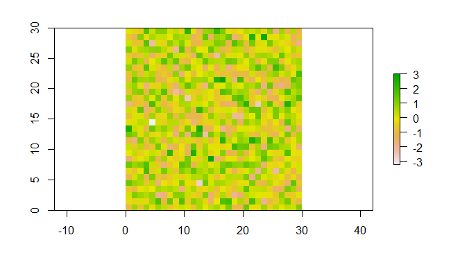

```r
ras2 <- raster(nrows=30,ncols=30,xmn=0,xmx=30,ymn=0,ymx=30)
ras2[] = rnorm(ncell(ras2))
plot(ras2)
```

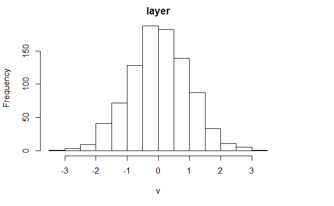

```r
hist(ras2)
```

### 3c

Create a third raster (30 rows × 30 columns) and assign values to the raster based on cell-by-cell addition of the first raster and the second raster. Plot the raster and the histogram. (5 pt.)

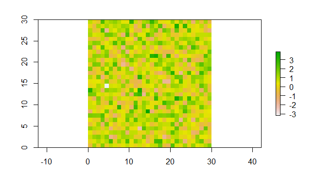

```r
ras3 <- ras1 + ras2
plot(ras3)
```

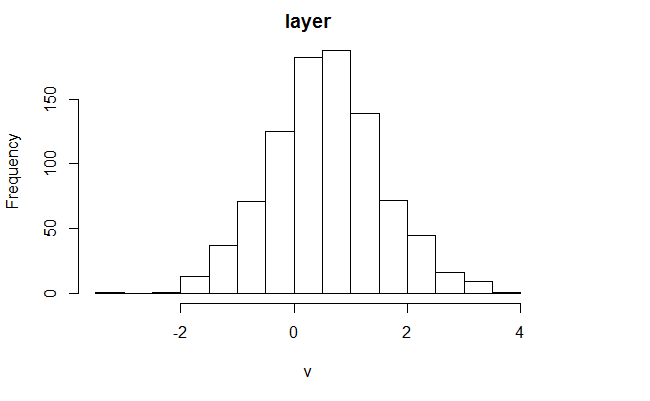

```r
hist(ras3)
```

### 3d

Calculate the mean value of the third raster. Reclassify the third raster into a binary image: 1 (cell value > mean value) and 0 (cell value <= mean value). Save the reclassified image to your working directory as a TIFF image. (5 pt.)

```r
mean(ras3)
```

```
class       : RasterLayer
dimensions  : 30, 30, 900  (nrow, ncol, ncell)
resolution  : 1, 1  (x, y)
extent      : 0, 30, 0, 30  (xmin, xmax, ymin, ymax)
coord. ref. : +proj=longlat +datum=WGS84 +ellps=WGS84 +towgs84=0,0,0
data source : in memory
names       : layer
values      : -3.180491, 3.899627  (min, max)
```

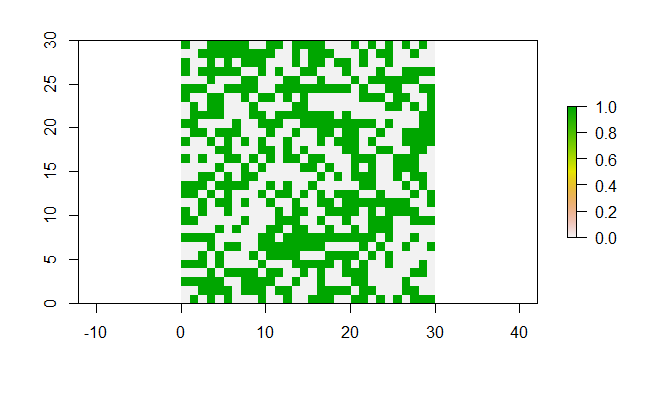

```r
m <- cellStats(ras3,mean)
ras3[ras3 < m] <- 0
ras3[ras3 >= m] <- 1
plot(ras3)
```

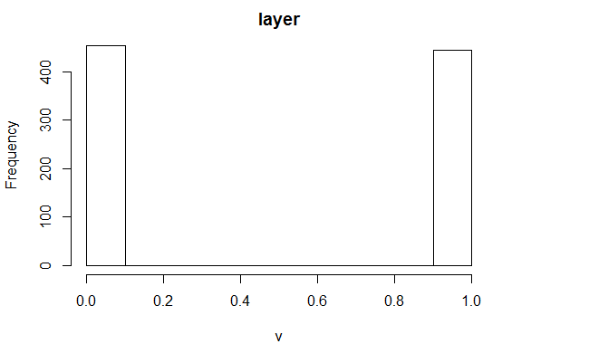

```r
hist(ras3)
```

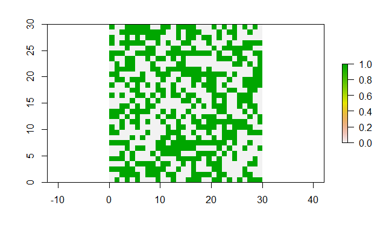

```r
writeRaster(ras3,filename = "test.tif")
r <- raster("test.tif")
plot(r)
```

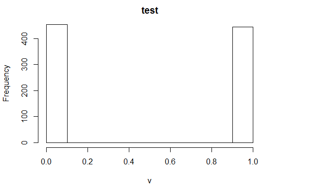

```r
hist(r)
```